# Data Wrangling Project

Tom Gocken

Wednesday, January 20, 2016

### Step 1: Load CDC environmental datasets

- Data for counties of interest was queried from http://wonder.cdc.gov/EnvironmentalData.html
- County coordinates from https://www.census.gov/geo/maps-data/data/gazetteer.html
- Each environmental data type was downloaded in its own tab-delimited file and a dataset was created for each file.

```r
setwd("C:/Projects/springboard-wrangling")
airtemp <- read.delim("../data/Air Temperature.txt")
precip <- read.delim("../data/Precipitation.txt")
sunlight <- read.delim("../data/Sunlight.txt")
surfacetemp <- read.delim("../data/Surface Temperature.txt")
particulate <- read.delim("../data/Particulate Matter.txt")
coordinates <- read.delim("../data/County Coordinates.txt")
```

### Step 2: Manage NA’s

- **dplyr** package loaded for wrangling functions.

```r
library(dplyr)
```

- Missing numeric values from certain columns in original files were populated with the string “Missing”.
- “Missing” strings were converted to NA using **type.convert** function.

```r
airtemp <- mutate(airtemp, heat_index =
                    type.convert(as.character(Avg.Daily.Max.Heat.Index..F.),
                                 na.strings = "Missing"))

surfacetemp <- mutate(surfacetemp, day_surface_temp =
                        type.convert(as.character(
                          Avg.Day.Land.Surface.Temperature..F.),
                          na.strings = "Missing"),
                      night_surface_temp = type.convert(as.character(
                        Avg.Night.Land.Surface.Temperature..F.),
                        na.strings = "Missing"))
```

Note: The same result could have been accomplished using **gsub** function:

```
airtemp <- mutate(airtemp, heat_index = as.numeric(gsub("Missing",
NA, as.character((airtemp$Avg.Daily.Max.Heat.Index..F.)))))
```

### Step 3: Load and reshape monthly ERSST data measuring El Nino / La Nina effects

- Data source: http://www.cpc.noaa.gov/products/analysis_monitoring/ensostuff/ensoyears.shtml

```r
el_nino <- read.csv("../data/el_nino.csv")
el_nino <- dplyr::rename(el_nino, year = Year, "1" = DJF, "2" = JFM, "3" = FMA,
                         "4" = MAM, "5" = AMJ, "6" = MJJ, "7" = JJA, "8" = JAS,
                         "9" = ASO, "10" = SON, "11" = OND, "12" = NDJ)
el_nino_tidy <- tidyr::gather(el_nino, "month", "ersst", 2:13)
el_nino_tidy$month <- as.integer(el_nino_tidy$month)
```

- Add 3 and 6 month lag variables

```r
el_nino_lag <- dplyr::mutate(el_nino_tidy,
                             yr_lag3mo = as.integer(ifelse(month < 10, year, year + 1)),
                             mo_lag3mo = as.integer(ifelse(month < 10, month + 3, month - 9)),
                             yr_lag6mo = as.integer(ifelse(month < 7, year, year + 1)),
                             mo_lag6mo = as.integer(ifelse(month < 7, month + 6, month - 6)))
el_nino_lag3mo <- dplyr::select(el_nino_lag, year = yr_lag3mo,
                                month = mo_lag3mo, ersst_lag3mo = ersst)
el_nino_lag6mo <- dplyr::select(el_nino_lag, year = yr_lag6mo,
                                month = mo_lag6mo, ersst_lag6mo = ersst)
el_nino_all <- dplyr::left_join(el_nino_tidy, el_nino_lag3mo)
el_nino_all <- dplyr::left_join(el_nino_all, el_nino_lag6mo)
el_nino_all <- dplyr::arrange(el_nino_all, year, month)
```

### Step 4: Join data into a single tidy dataset

```r
joindat <- left_join(airtemp, precip)
joindat <- left_join(joindat, sunlight)
joindat <- left_join(joindat, surfacetemp)
joindat <- left_join(joindat, particulate)
joindat <- left_join(joindat, coordinates)
joindat <- left_join(joindat, el_nino_all, by = c("Year" = "year", "Month.Code" = "month"))
```

Date variable created by concatenating year, month, and day columns and coverting to date class.

```r
joindat <- mutate(joindat, date = as.Date(paste(joindat$Year.Code,
                                                joindat$Month.Code,
                                                joindat$Day.of.Month.Code,
                                                sep="-")))
```

Select statement used to assign concise variable names in common format to columms of interest.

```r
envdat <- select(joindat,
                 county = County,
                 latitude = Latitude,
                 longitude = Longitude,
                 year = Year,
                 month = Month.Code,
                 day_of_yr = Day.of.Year,
                 date,
                 max_air_temp = Avg.Daily.Max.Air.Temperature..F.,
                 min_air_temp = Avg.Daily.Min.Air.Temperature..F.,
                 heat_index,
                 precip = Avg.Daily.Precipitation..mm.,
                 sunlight = Avg.Daily.Sunlight..KJ.m².,
                 day_surface_temp,
                 night_surface_temp,
                 particulate_matter = Avg.Fine.Particulate.Matter..µg.m³.,
                 ersst,
                 ersst_lag3mo,
                 ersst_lag6mo
                 )
```

Growing degree units (GDUs), also known as growing degree days, were calculated by taking the average of the daily maximum and minimum temperatures compared to a base temperature, T(base), as follows:

GDU = ((T(max) + T(min)) / 2) - T(base)

Accumulated GDUs (AGDUs) were calculated using the **cumsum** function grouped by county and year and ordered by date. AGDUs provide a standard measure of accumulated heat during a growing season. The maturity of a plant variety is often expressed in AGDUs after planting, rather than days, since days to maturity vary by location and season.

References:  
http://en.wikipedia.org/wiki/Growing_degree-day  
http://agron-www.agron.iastate.edu/Courses/agron212/Calculations/GDD.htm

```r
envdat <- mutate(envdat, gdu = ifelse(max_air_temp < 50, 0,
                 (((ifelse(max_air_temp > 86, 86, max_air_temp)
                 + ifelse(min_air_temp < 50, 50, min_air_temp)) / 2) - 50)))

envdat <- transform(envdat, agdu = ave(gdu, paste(county, year),
                                       FUN = cumsum))

# Save results for future use
write.table(envdat, "../data/envdat.txt", sep = "\t")
```

### Step 5: Summarize and view data

```r
summary(envdat)
```

```
##                     county        latitude       longitude
##  Columbia County, WI   :7305   Min.   :38.02   Min.   :-92.06
##  Darke County, OH      :7305   1st Qu.:40.13   1st Qu.:-89.33
##  DeKalb County, IL     :7305   Median :41.68   Median :-88.77
##  Iowa County, IA       :7305   Mean   :41.04   Mean   :-88.47
##  Vanderburgh County, IN:7305   3rd Qu.:41.89   3rd Qu.:-87.59
##                                Max.   :43.47   Max.   :-84.62
##
##       year          month          day_of_yr          date
##  Min.   :1992   Min.   : 1.000   Min.   :  1.0   Min.   :1992-01-01
##  1st Qu.:1996   1st Qu.: 4.000   1st Qu.: 92.0   1st Qu.:1996-12-31
##  Median :2001   Median : 7.000   Median :183.0   Median :2001-12-31
##  Mean   :2001   Mean   : 6.523   Mean   :183.1   Mean   :2001-12-31
##  3rd Qu.:2006   3rd Qu.:10.000   3rd Qu.:274.0   3rd Qu.:2006-12-31
##  Max.   :2011   Max.   :12.000   Max.   :366.0   Max.   :2011-12-31
##
##   max_air_temp     min_air_temp      heat_index         precip
##  Min.   :-16.81   Min.   :-34.48   Min.   : 78.40   Min.   :  0.000
##  1st Qu.: 41.12   1st Qu.: 28.58   1st Qu.: 84.10   1st Qu.:  0.000
##  Median : 62.17   Median : 43.37   Median : 88.35   Median :  0.100
##  Mean   : 59.32   Mean   : 42.48   Mean   : 90.22   Mean   :  2.754
##  3rd Qu.: 78.13   3rd Qu.: 58.40   3rd Qu.: 94.80   3rd Qu.:  1.900
##  Max.   :114.08   Max.   : 84.07   Max.   :128.49   Max.   :133.900
##                                    NA's   :28356
##     sunlight     day_surface_temp night_surface_temp particulate_matter
##  Min.   : 1450   Min.   : -8.23   Min.   :-26.27     Min.   : 0.00
##  1st Qu.: 8334   1st Qu.: 47.97   1st Qu.: 24.80     1st Qu.: 8.30
##  Median :14337   Median : 71.75   Median : 42.29     Median :12.03
##  Mean   :14768   Mean   : 63.88   Mean   : 39.20     Mean   :13.14
##  3rd Qu.:20725   3rd Qu.: 81.42   3rd Qu.: 55.77     3rd Qu.:16.56
##  Max.   :30876   Max.   :108.53   Max.   : 77.10     Max.   :55.30
##                  NA's   :28644    NA's   :28042      NA's   :20090
##      ersst           ersst_lag3mo        ersst_lag6mo
##  Min.   :-1.60000   Min.   :-1.600000   Min.   :-1.60000
##  1st Qu.:-0.70000   1st Qu.:-0.600000   1st Qu.:-0.60000
##  Median : 0.00000   Median : 0.000000   Median : 0.00000
##  Mean   :-0.02597   Mean   :-0.001164   Mean   : 0.01387
##  3rd Qu.: 0.50000   3rd Qu.: 0.500000   3rd Qu.: 0.50000
##  Max.   : 2.30000   Max.   : 2.300000   Max.   : 2.30000
##
##       gdu              agdu
##  Min.   : 0.000   Min.   :   0.00
##  1st Qu.: 0.000   1st Qu.:  83.41
##  Median : 6.185   Median :1275.78
##  Mean   : 9.547   Mean   :1577.38
##  3rd Qu.:18.200   3rd Qu.:2916.39
##  Max.   :35.035   Max.   :4957.62
##
```

Box plot and line graphs created using **ggplot2**.

```r
library(ggplot2)
```

Differences in max air temp by year and county (2009-2011):

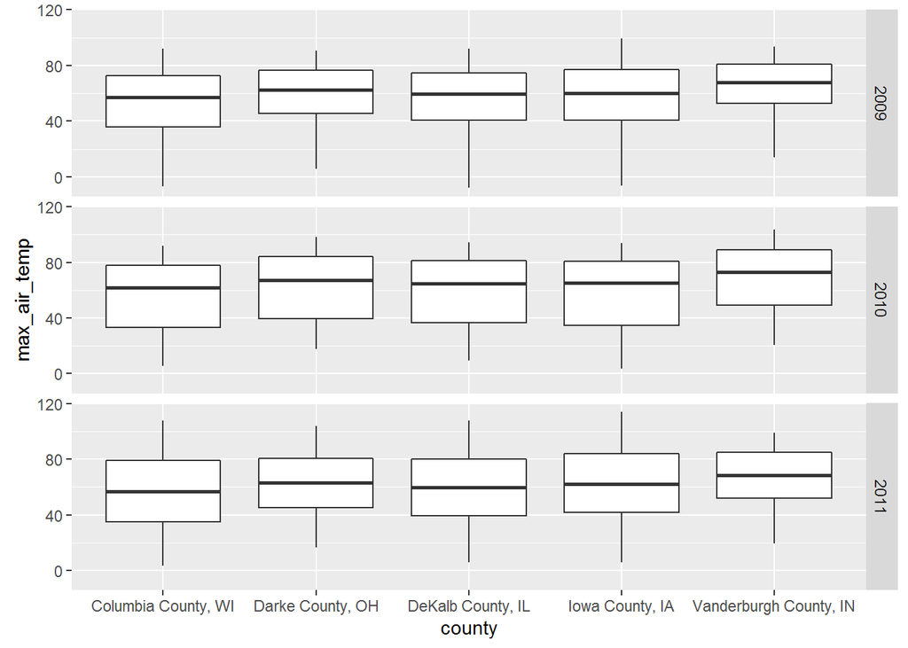

```r
envdat_3yr <- filter(envdat, year %in% c(2009, 2010, 2011))
envdat_3yr$year <- as.factor(envdat_3yr$year)
qplot(county, max_air_temp, data = envdat_3yr, geom = "boxplot",
      facets = year ~ .)
```

Differences in accumulated GDUs by county, across years:

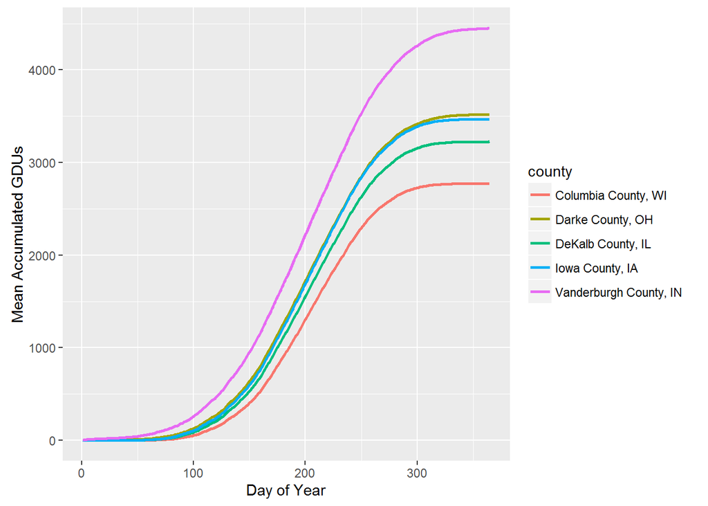

```r
county_means <- envdat %>%
  filter(day_of_yr != 366) %>% # exclude extra leap year day
  group_by(county, day_of_yr) %>%
  summarize(agdu_mean = mean(agdu))

qplot(day_of_yr, agdu_mean, data = county_means, geom = "line", color = county,
      xlab = "Day of Year", ylab = "Mean Accumulated GDUs") + geom_line(size = 1.0)
```

Differences in accumulated GDUs by 5-year means, across counties:

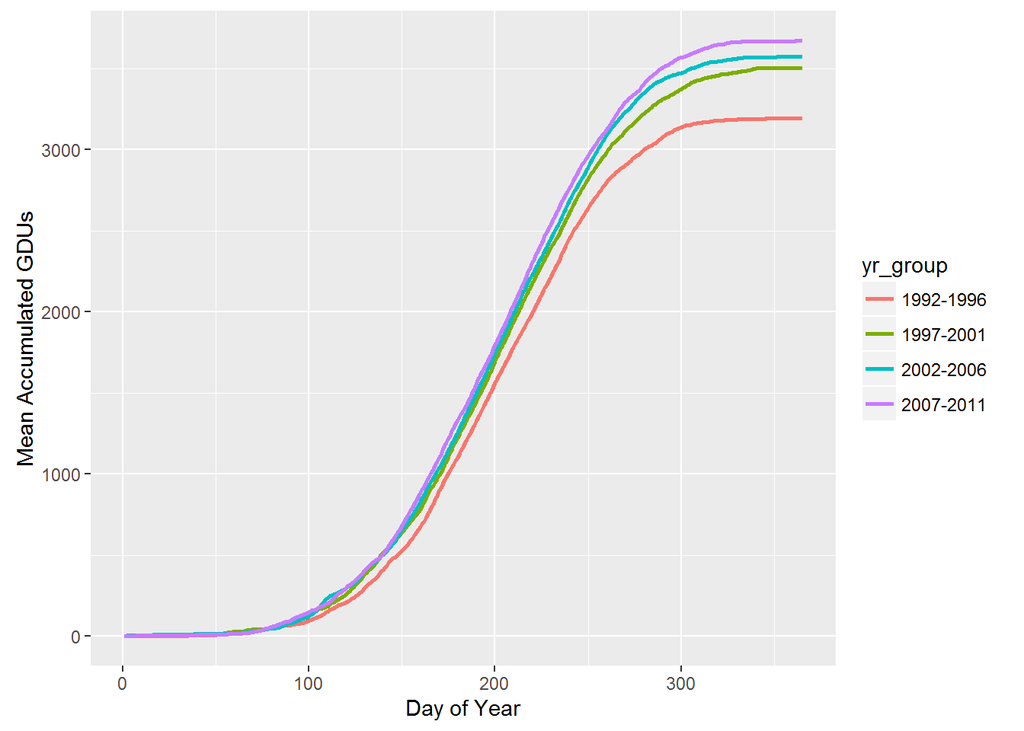

```r
envdat <- mutate(envdat, yr_group = ifelse(year < 1997, "1992-1996",
                                      ifelse(year < 2002, "1997-2001",
                                        ifelse(year < 2007, "2002-2006",
                                          "2007-2011"))))
yr_means <- envdat %>%
  filter(day_of_yr != 366) %>% # exclude extra leap year day
  group_by(yr_group, day_of_yr) %>%
  summarize(agdu_mean = mean(agdu))

qplot(day_of_yr, agdu_mean, data = yr_means, geom = "line",
      color = yr_group, xlab = "Day of Year",
      ylab = "Mean Accumulated GDUs") + geom_line(size = 1.0)
```